# Applied Data Analysis in Sport

Assessment 4: Reproducible Data Analysis Project

Siqi (Liam) Wu

Semester 1 2022

# Introduction

## a) case description

Basketball consist of five players on the floor on each side. There are: Center, Power Forward, Small Forward, Shooting Guard, Point Guard. The center is the core of defence. The power forward will help center near the paint area. The small forward and shooting guard are the major scoring players for most teams. The point guard is the brain of the team and the job is to connect all the others in offence.

## b) background info

In the recent season of 2018-19, our team - Chicago Bulls placed 27th out of 30. This is not what we want. We need a significant overhaul to improve our performance. With a budget of $118 million for the next season, we need to find best players for the win.

## c) project objectives

This project tries to identify the most important stats for a team to win. And then, we will try to find the players that can best provide these values for the team based on the analysis.

## d) justification and importance

Without proper analysis, we may fall into the trap of chasing the highest pay players instead of the players that can really contribute to the win.

# Reading and cleaning the raw data

## a) description of datasets

- NBA player statistics (2018-19): `2018-19_nba_player-statistics.csv` [source](https://www.basketball-reference.com/leagues/NBA_2019_totals.html)
- NBA player salaries (2018-19): `2018-19_nba_player-salaries.csv` [source](https://hoopshype.com/salaries/)
- NBA team payrolls (2019-20): `2019-20_nba_team-payroll.csv` [source](https://hoopshype.com/salaries/players/)
- NBA team advanced statistics (2018-19): `2018-19_nba_team-statistics_1.csv` [source](https://www.basketball-reference.com/leagues/NBA_2019.html)
- NBA team total statistics (2018-19): `2018-19_nba_team-statistics_2.csv` [source](https://www.basketball-reference.com/leagues/NBA_2019.html)

## b) load the raw datasets into R environment

```r
# Unzip the raw data file under data folder.
unzipped <- "data/project-data/" # dir of unzipped file

if (!dir.exists(unzipped)) {
  unzip("data/raw/project-data.zip", exdir = "data")
}

# Load the unzipped raw datasets.
filenames <- list.files(unzipped)

for (name in filenames) {
  # extract and assign tibble names from files
  assign(
    str_replace_all(str_extract(name, "(?<=a_).+(?=\\.)"), "-", "_"),
    read_csv(paste0(unzipped, name))
  )
}
```

## c) check and clean the raw data

```r
# Check the datasets
glimpse(player_salaries)
view(player_salaries)

glimpse(player_statistics)
view(player_statistics)

glimpse(team_statistics_1)
view(team_statistics_1)

glimpse(team_statistics_2)
view(team_statistics_2)

glimpse(team_payroll)
view(team_payroll)
```

```r
# Combine datasets for the players.
player_data <-
  # join by player names column
  left_join(
    player_statistics,
    player_salaries,
    by = "player_name",
  ) %>%
  # rename columns for naming consistency and other issues
  rename(
    Player = player_name,
    Salary = salary,
    FGP = "FG%",
    LS = "3P", # name 3-pointer as long shot (LS)
    LSA = "3PA",
    LSP = "3P%",
    NS = "2P", # name 2-pointer as normal shot (NS)
    NSA = "2PA",
    NSP = "2P%",
    EFG = "eFG%",
    FTP = "FT%"
  ) %>%
  # drop redundant column
  select(- "player_id")

# Clean and combine datasets for the teams.
team_payroll <-
  # rename columns for naming consistency
  team_payroll %>%
    rename(
      Team = team,
      Salary = salary
    )

team_data <-
  # join by team names column
  full_join(
    team_statistics_2,
    team_statistics_1,
    by = "Team",
  ) %>%
  # rename ambiguous columns and fix other issues
  rename(
    Rk_ttl = Rk.x, # total stats ranking
    Rk_adv = Rk.y, # advanced stats ranking
    FGP = "FG%",
    LS = "3P", # name 3-pointer as long shot (LS)
    LSA = "3PA",
    LSP = "3P%",
    NS = "2P", # name 2-pointer as normal shot (NS)
    NSA = "2PA",
    NSP = "2P%",
    EFG = "eFG%",
    FTP = "FT%",
    LSAr = "3PAr",
    TSP = "TS%",
    TOVP = "TOV%",
    ORBP = "ORB%",
    DRBP = "DRB%",
    FTOFGA = "FT/FGA"
  ) %>%
  # drop empty columns
  select(- c(47, 48, 49))

# Save them as csv file into `/tidy` folder of processed data.
dir.create("data/tidy/")
write_csv(team_data, file = "data/tidy/2018-19_team.csv")
write_csv(player_data, file = "data/tidy/2018-19_player.csv")
```

# Exploratory analysis

## a) checking for errors and missings

For the player dataset, there are NAs in certain columns of stats and salary. For the stats, those NAs come from percentage of different types of shots, it means they made no shot for this type. A defence focused centre could have made no long shot and a rookie could have got no free-throw for a whole season, which is normal. So they are not errors. The eFG% is a combo metric of all shots made, it can be not available if there is no shots made at all. Those NAs are replace with 0s. For salary, the NAs could mean the contracts had been broken or other issues. Since it is not a large number, in this project, we can treat them as outliers and drop them. There is no NAs in the team dataset.

## b) select important variables in team stats

To find best players, it is important to find the stats that are important to the wins. In this case, promising ones are selected to investigate: PTS (points scored), EFG (effective field goal percentage), AST (assist), TRB (total rebounds). They are common stats to evaluate performance of a game or a player.

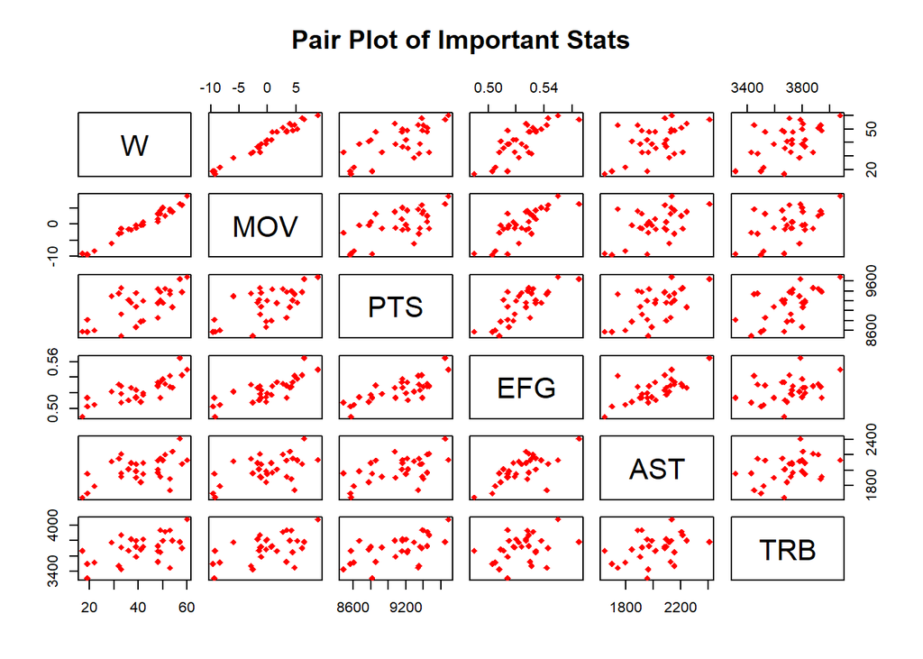

```r
team_data %>%
  select(W, MOV, PTS, EFG, AST, TRB) %>%
  pairs(col = "red", pch = 18, main = "Pair Plot of Important Stats")
```

## c) checking for variable distributions

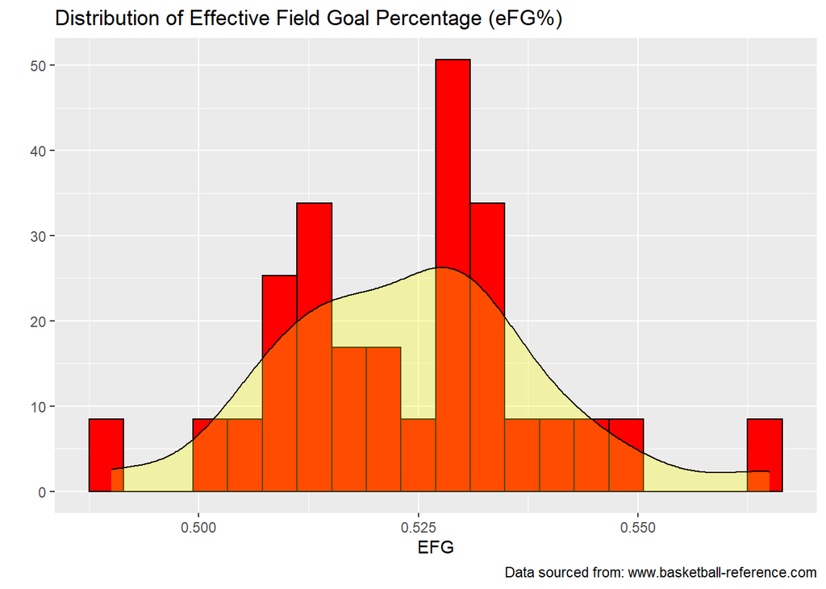

```r
# Distribution of effective field goal percentage
ggplot(data = team_data, aes(x = EFG)) +
  geom_histogram(
    mapping = aes(y = ..density..),
    bins = 20, colour = "black", fill = "red") +
    geom_density(alpha = 0.3, fill = "yellow") +
    labs(
      title = "Distribution of Effective Field Goal Percentage (eFG%)",
      caption = "Data sourced from: www.basketball-reference.com",
      y = "",
    )
```

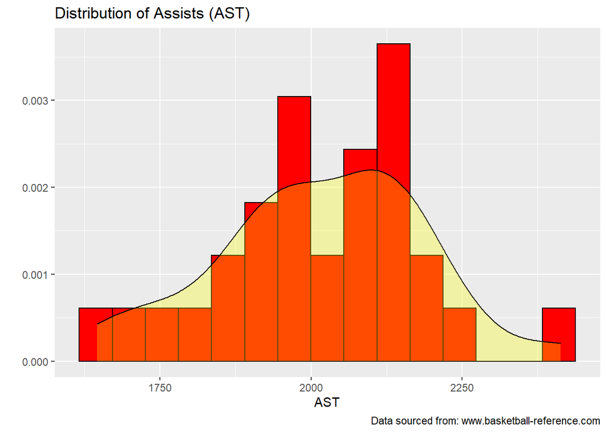

```r
# Distribution of assists
ggplot(data = team_data, aes(x = AST)) +
  geom_histogram(
    mapping = aes(y = ..density..),
    bins = 15, colour = "black", fill = "red") +
    geom_density(alpha = 0.3, fill = "yellow") +
    labs(
      title = "Distribution of Assists (AST)",
      caption = "Data sourced from: www.basketball-reference.com",
      y = "",
    )
```

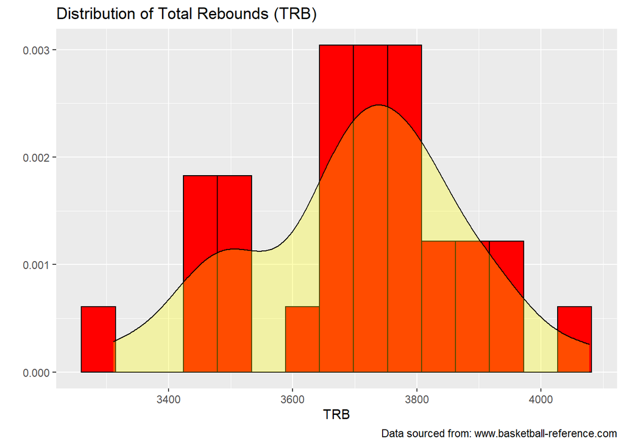

```r
# Distribution of total rebounds
ggplot(data = team_data, aes(x = TRB)) +
  geom_histogram(
    mapping = aes(y = ..density..),
    bins = 15, colour = "black", fill = "red") +
    geom_density(alpha = 0.3, fill = "yellow") +
    labs(
      title = "Distribution of Total Rebounds (TRB)",
      caption = "Data sourced from: www.basketball-reference.com",
      y = "",
    )
```

## c) checking for differences between groups

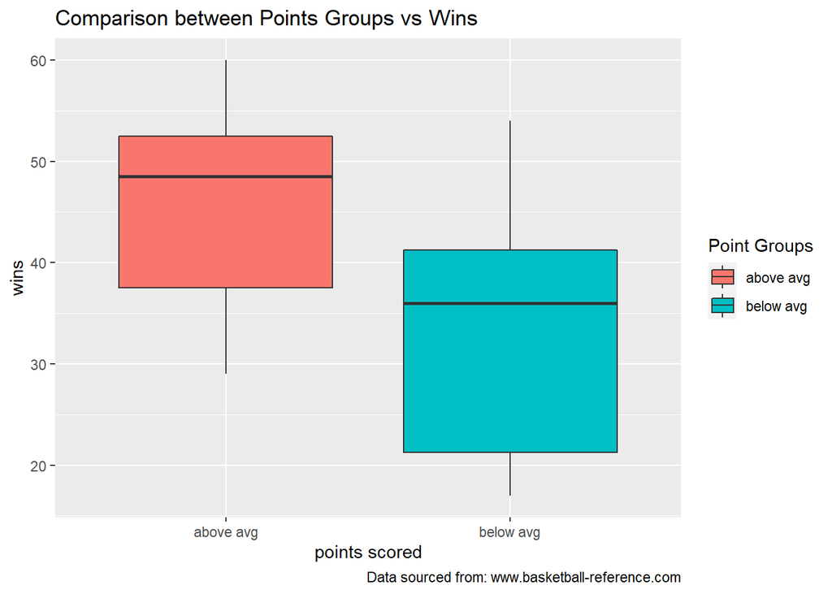

```r
# Comparison between groups of points scored
ggplot(data = team_data, aes(x = pts_group, y = W)) +
  geom_boxplot(aes(fill = pts_group)) +
    labs(
      title = "Comparison between Points Groups vs Wins",
      caption = "Data sourced from: www.basketball-reference.com",
      x = "points scored",
      y = "wins",
      fill = "Point Groups"
    )
```

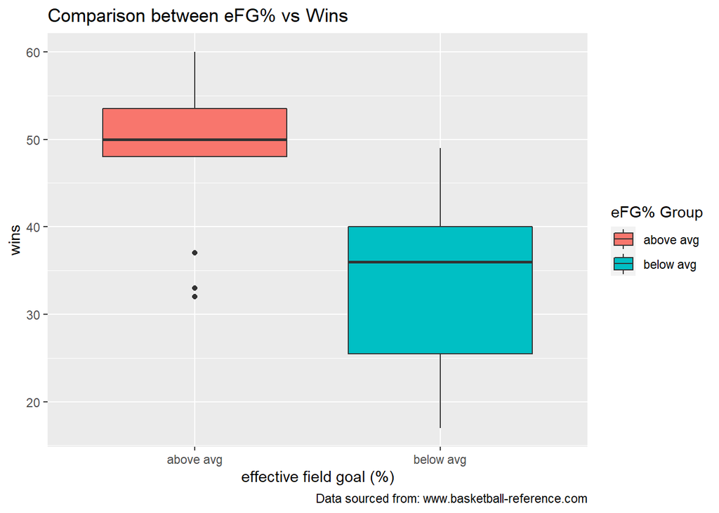

```r
# Comparison between groups of effective field goal percentage
ggplot(data = team_data, aes(x = efg_group, y = W)) +
  geom_boxplot(aes(fill = efg_group)) +
    labs(
      title = "Comparison between eFG% vs Wins",
      caption = "Data sourced from: www.basketball-reference.com",
      x = "effective field goal (%)",
      y = "wins",
      fill = "eFG% Group"
    )
```

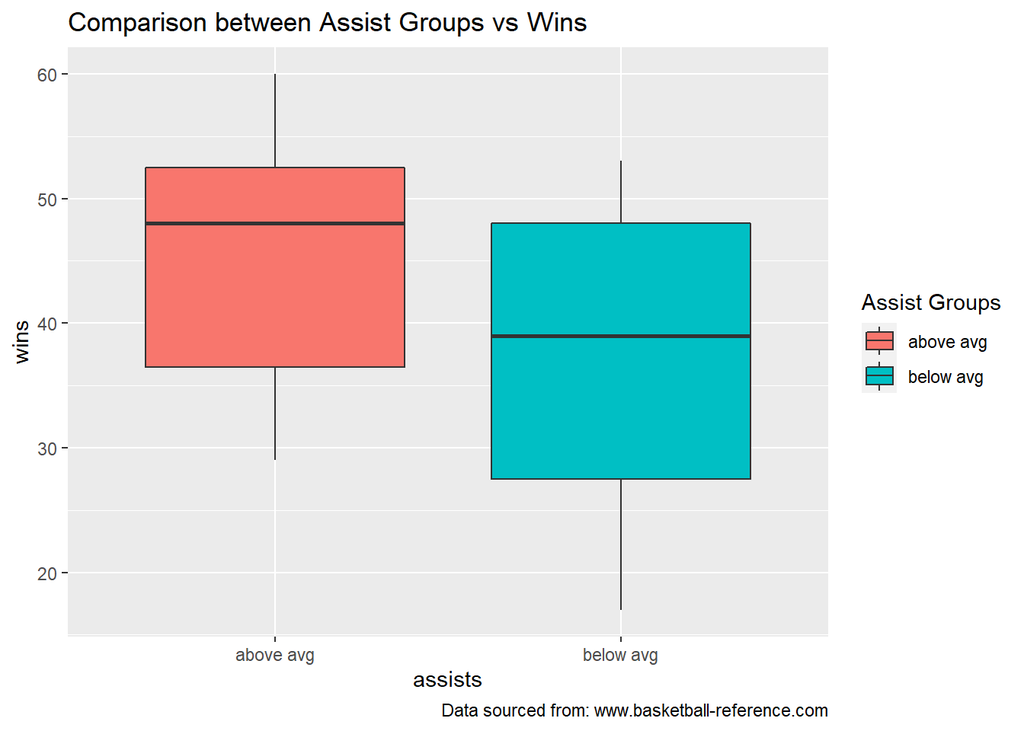

```r
# Comparison between groups of assists
ggplot(data = team_data, aes(x = ast_group, y = W)) +
  geom_boxplot(aes(fill = ast_group)) +
    labs(
      title = "Comparison between Assist Groups vs Wins",
      caption = "Data sourced from: www.basketball-reference.com",
      x = "assists",
      y = "wins",
      fill = "Assist Groups"
    )
```

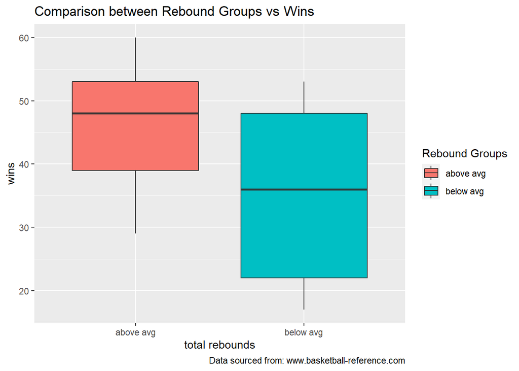

```r
# Comparison between groups of total rebounds
ggplot(data = team_data, aes(x = trb_group, y = W)) +
  geom_boxplot(aes(fill = trb_group)) +
    labs(
      title = "Comparison between Rebound Groups vs Wins",
      caption = "Data sourced from: www.basketball-reference.com",
      x = "total rebounds",
      y = "wins",
      fill = "Rebound Groups"
    )
```

# Data modelling and results

## a) modelling

```r
# Fit linear regression with multiple predictors
lm_data <- team_data %>% select(W, PTS, EFG, AST, TRB)

team_fit <- lm(W ~ ., data = lm_data)
tidy(team_fit, conf.int = T)
```

| term | estimate | std.error | statistic | p.value | conf.low | conf.high |
| --- | --- | --- | --- | --- | --- | --- |
| (Intercept) | -354.2361598 | 53.6075712 | -6.6079502 | 0.0000006 | -464.6430195 | -243.8293001 |
| PTS | -0.0055933 | 0.0071782 | -0.7792084 | 0.4431710 | -0.0203770 | 0.0091904 |
| EFG | 713.9604756 | 161.9072549 | 4.4096880 | 0.0001721 | 380.5062422 | 1047.4147090 |
| AST | -0.0132043 | 0.0107965 | -1.2230117 | 0.2327293 | -0.0354401 | 0.0090316 |
| TRB | 0.0266308 | 0.0094911 | 2.8058756 | 0.0095768 | 0.0070835 | 0.0461780 |

## b) assumption checking

```r
# Check multicollinearity between variables
sqrt(vif(team_fit))
```

```
##      PTS      EFG      AST      TRB
## 1.869440 1.915735 1.434899 1.277922
```

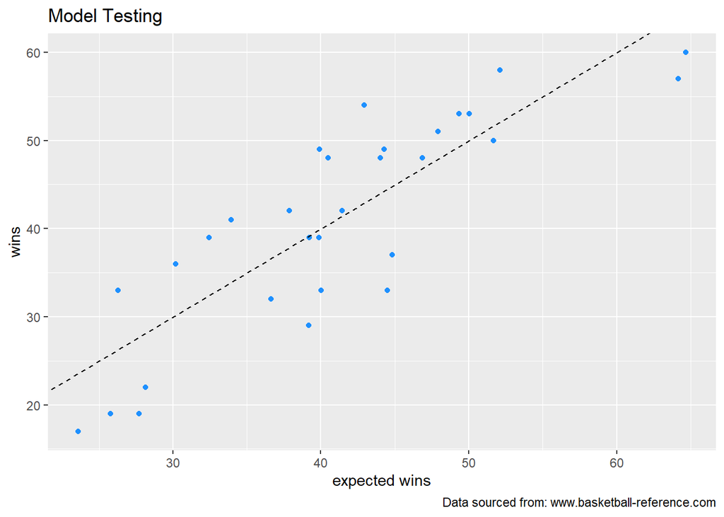

```r
# Using the model to predict expected wins
lm_data <- lm_data %>% mutate(exp_win = predict(team_fit, newdata = lm_data))

lm_data %>%
    ggplot(aes(x = exp_win, y = W)) +
        geom_point(colour = "dodgerblue") +
        geom_abline(linetype = "dashed", colour = "black") +
        labs(
          title = "Model Testing",
          caption = "Data sourced from: www.basketball-reference.com",
          x = "expected wins",
          y = "wins"
        )
```

## c) output and interpretation

# Player recommendations

```r
# Ranking for Center
rank_data %>%
  filter(Pos == "C") %>%
  arrange(desc(PTSPG), desc(TRBPG), desc(EFG), desc(ASTPG)) %>%
  head(5)
```

| Player | Pos | G | PTS | EFG | AST | TRB | Salary | PTSPG | ASTPG | TRBPG |
| --- | --- | --- | --- | --- | --- | --- | --- | --- | --- | --- |
| Joel Embiid | C | 64 | 1761 | 0.517 | 234 | 871 | 25467250 | 27.51562 | 3.656250 | 13.609375 |
| Anthony Davis | C | 56 | 1452 | 0.540 | 218 | 672 | 25434263 | 25.92857 | 3.892857 | 12.000000 |
| Karl-Anthony Towns | C | 77 | 1880 | 0.572 | 259 | 954 | 7839435 | 24.41558 | 3.363636 | 12.389610 |
| LaMarcus Aldridge | C | 81 | 1727 | 0.522 | 194 | 744 | 22347015 | 21.32099 | 2.395062 | 9.185185 |
| Nikola Vucevic | C | 80 | 1665 | 0.549 | 307 | 960 | 12750000 | 20.81250 | 3.837500 | 12.000000 |

```r
# Ranking for Power Forward
rank_data %>%
  filter(Pos == "PF") %>%
  arrange(desc(PTSPG), desc(TRBPG), desc(EFG), desc(ASTPG)) %>%
  head(5)
```

| Player | Pos | G | PTS | EFG | AST | TRB | Salary | PTSPG | ASTPG | TRBPG |
| --- | --- | --- | --- | --- | --- | --- | --- | --- | --- | --- |
| Giannis Antetokounmpo | PF | 72 | 1994 | 0.599 | 424 | 898 | 24157304 | 27.69444 | 5.888889 | 12.472222 |
| Blake Griffin | PF | 75 | 1841 | 0.532 | 402 | 565 | 31873932 | 24.54667 | 5.360000 | 7.533333 |
| Julius Randle | PF | 73 | 1565 | 0.555 | 229 | 634 | 8641000 | 21.43836 | 3.136986 | 8.684931 |
| Tobias Harris | PF | 55 | 1152 | 0.561 | 150 | 432 | 14800000 | 20.94545 | 2.727273 | 7.854546 |
| Tobias Harris | PF | 82 | 1644 | 0.549 | 229 | 645 | 14800000 | 20.04878 | 2.792683 | 7.865854 |

```r
# Ranking for Small Forward
rank_data %>%
  filter(Pos == "SF") %>%
  arrange(desc(PTSPG), desc(EFG), desc(ASTPG), desc(TRBPG)) %>%
  head(5)
```

| Player | Pos | G | PTS | EFG | AST | TRB | Salary | PTSPG | ASTPG | TRBPG |
| --- | --- | --- | --- | --- | --- | --- | --- | --- | --- | --- |
| Paul George | SF | 77 | 2159 | 0.529 | 318 | 628 | 30560700 | 28.03896 | 4.129870 | 8.155844 |
| LeBron James | SF | 55 | 1505 | 0.560 | 454 | 465 | 35654150 | 27.36364 | 8.254546 | 8.454546 |
| Kawhi Leonard | SF | 60 | 1596 | 0.546 | 199 | 439 | 23114066 | 26.60000 | 3.316667 | 7.316667 |
| Kevin Durant | SF | 78 | 2027 | 0.571 | 457 | 497 | 30000000 | 25.98718 | 5.858974 | 6.371795 |
| JaKarr Sampson | SF | 4 | 80 | 0.583 | 4 | 32 | 85457 | 20.00000 | 1.000000 | 8.000000 |

```r
# Ranking for Shooting Guard
rank_data %>%
  filter(Pos == "SG") %>%
  arrange(desc(PTSPG), desc(EFG), desc(ASTPG), desc(TRBPG)) %>%
  head(5)
```

| Player | Pos | G | PTS | EFG | AST | TRB | Salary | PTSPG | ASTPG | TRBPG |
| --- | --- | --- | --- | --- | --- | --- | --- | --- | --- | --- |
| Devin Booker | SG | 64 | 1700 | 0.521 | 433 | 265 | 3314365 | 26.56250 | 6.765625 | 4.140625 |
| Bradley Beal | SG | 82 | 2099 | 0.540 | 448 | 411 | 25434262 | 25.59756 | 5.463415 | 5.012195 |
| Donovan Mitchell | SG | 77 | 1829 | 0.493 | 322 | 316 | 3111480 | 23.75325 | 4.181818 | 4.103896 |
| Zach LaVine | SG | 63 | 1492 | 0.520 | 283 | 294 | 19500000 | 23.68254 | 4.492064 | 4.666667 |
| Klay Thompson | SG | 78 | 1680 | 0.553 | 186 | 299 | 18988725 | 21.53846 | 2.384615 | 3.833333 |

```r
# Ranking for Point Guard
rank_data %>%
  filter(Pos == "PG") %>%
  arrange(desc(ASTPG), desc(PTSPG), desc(EFG), desc(TRBPG)) %>%
  head(5)
```

| Player | Pos | G | PTS | EFG | AST | TRB | Salary | PTSPG | ASTPG | TRBPG |
| --- | --- | --- | --- | --- | --- | --- | --- | --- | --- | --- |
| Russell Westbrook | PG | 73 | 1675 | 0.468 | 784 | 807 | 35665000 | 22.94521 | 10.739726 | 11.054794 |
| John Wall | PG | 32 | 663 | 0.490 | 279 | 116 | 19169800 | 20.71875 | 8.718750 | 3.625000 |
| Kyle Lowry | PG | 65 | 926 | 0.518 | 564 | 312 | 32700000 | 14.24615 | 8.676923 | 4.800000 |
| Jeff Teague | PG | 42 | 510 | 0.465 | 343 | 106 | 19000000 | 12.14286 | 8.166667 | 2.523810 |
| Chris Paul | PG | 58 | 906 | 0.508 | 473 | 265 | 35654150 | 15.62069 | 8.155172 | 4.568966 |

Total salary: `$69.6` million (`$48.4` mil for others)

# Summary

# Reference

1. Wickham et al., (2019). Welcome to the tidyverse. Journal of Open Source Software, 4(43), 1686, https://doi.org/10.21105/joss.01686
2. H. Wickham. ggplot2: Elegant Graphics for Data Analysis. Springer-Verlag New York, 2016.
3. David Robinson, Alex Hayes and Simon Couch (2021). broom: Convert Statistical Objects into Tidy Tibbles. R package version 0.7.9. https://CRAN.R-project.org/package=broom
4. John Fox and Sanford Weisberg (2019). An {R} Companion to Applied Regression, Third Edition. Thousand Oaks CA: Sage. URL: https://socialsciences.mcmaster.ca/jfox/Books/Companion/